# Neural Representations of Multilayer Social Network Information: Conformity

Ovidia Stanoi

4/12/2025

In this script, we investigate whether participants with higher vmPFC sensitivity to peers’ dual status score higher on the reversed Resistance to Peer Influence (RPI) scale (model 1) and whether they tend to align their drinking habits in daily life more with the drinking norms of their groups (model 2).

Clear global environment.

```r
remove(list=ls())
```

Open packages.

```r
library("tidyverse")
library("corrplot")
library("reshape")
library("rstanarm")
library("glmmTMB")
library("sjPlot")
library("ggeffects")
library("bmlm")
library("brms")
library("broom.mixed")
library("modelsummary")
library("flextable")
library("kableExtra")
library("officer")
```

Set up ggplot theme.

```r
theme_set(theme_bw() +
            theme(plot.title = element_text(size=14, hjust = .5),
                  axis.text=element_text(size=12),
                  axis.title=element_text(size=13),
                  strip.text = element_text(size=12),
                  # plot.title = element_text(size=20, hjust = .5), # use this for .pdf version of figures instead of .html
                  # axis.text=element_text(size=20),  # use this for .pdf version of figures instead of .html
                  # axis.title=element_text(size=22), # use this for .pdf version of figures instead of .html
                  # axis.title.y = element_text(size = 20, lineheight = 1),
                  # strip.text = element_text(size=16),
                  axis.line = element_line(colour = "gray"),
                  panel.border = element_rect(colour = "gray"),
                  panel.grid.minor = element_blank(),
                  panel.background = element_rect(colour = "gray", linewidth = .8),
                  strip.background.x = element_rect(fill = "white", linetype = "solid",
                                                    color = "gray", linewidth = .8),
                  legend.position = "none"))
```

Set up the file directory.

```r
path <- ""
```

Read the dataset including each participant’s vmPFC neural responses to different faces and status information.

```r
d <- read.csv(sprintf("%s/Data/univariate_dataset.csv", path)) %>%
  filter(roi == "vmPFC") %>%
  select(groupID, pid, face, roi, neural_response, dual_relative_status_cw,
         face_mean_attractive_rating_cw, face_gender_cw,
         face_college_year_cw, face_educ_parents_cw, face_income_num_cw,
         pid_like_strength_in_cw, pid_leader_strength_in_cw,
         pid_mean_attractive_rating_cw, pid_gender_cw,
         pid_college_year_cw, pid_educ_parents_cw, pid_income_num_cw)
```

Check the format of the dataset.

```r
head(d)
```

|  | groupID | pid | face | roi | neural_response | dual_relative_status_cw | face_mean_attractive_rating_cw | face_gender_cw | face_college_year_cw | face_educ_parents_cw | face_income_num_cw | pid_like_strength_in_cw | pid_leader_strength_in_cw | pid_mean_attractive_rating_cw | pid_gender_cw | pid_college_year_cw | pid_educ_parents_cw | pid_income_num_cw |
| --- | --- | --- | --- | --- | --- | --- | --- | --- | --- | --- | --- | --- | --- | --- | --- | --- | --- | --- |
| 1 | g10p | muri369 | muri368 | vmPFC | -1.579338 | 0.07010922 | 0.59021630 | 1.149067 | -0.5206311 | -0.4354441 | -2.775558e-17 | -0.3495278 | -0.3592026 | -1.341401 | -1.149067 | 0.3313107 | 0.4354441 | 0.7786044 |
| 2 | g10p | muri369 | muri370 | vmPFC | 4.189737 | -0.01211436 | -0.05687539 | -1.149067 | -0.5206311 | -0.4354441 | 7.786044e-01 | -0.3495278 | -0.3592026 | -1.341401 | -1.149067 | 0.3313107 | 0.4354441 | 0.7786044 |
| 3 | g10p | muri369 | muri371 | vmPFC | 12.090102 | 0.26979504 | 0.10731205 | 1.149067 | 0.3313107 | 0.4354441 | 7.786044e-01 | -0.3495278 | -0.3592026 | -1.341401 | -1.149067 | 0.3313107 | 0.4354441 | 0.7786044 |
| 4 | g10p | muri369 | muri372 | vmPFC | 2.305773 | 0.55189237 | -1.02268387 | -1.149067 | 0.3313107 | 0.4354441 | 7.786044e-01 | -0.3495278 | -0.3592026 | -1.341401 | -1.149067 | 0.3313107 | 0.4354441 | 0.7786044 |
| 5 | g10p | muri369 | muri373 | vmPFC | -3.582554 | -0.26282578 | -0.21140475 | 1.149067 | -0.5206311 | 0.4354441 | 7.786044e-01 | -0.3495278 | -0.3592026 | -1.341401 | -1.149067 | 0.3313107 | 0.4354441 | 0.7786044 |
| 6 | g10p | muri369 | muri374 | vmPFC | 5.065963 | -0.17656151 | 0.10731205 | 1.149067 | -0.5206311 | 0.8708883 | 7.786044e-01 | -0.3495278 | -0.3592026 | -1.341401 | -1.149067 | 0.3313107 | 0.4354441 | 0.7786044 |

Run a regression model that estimates the participants’ neural responses to peers’ faces as a function of how much more status peers have relative to them in a **dual space that includes information from both the popularity and leadership dimension** (`dual_relative_status`) in the **vmPFC** (no other ROIs will be added to the model). The model includes random intercepts for both perceivers and targets, nested within groups, as well as a `dual_relative_status` random slope for perceivers, nested within groups. These perceiver-level dual_relative_status` slopes are what we are interested in. We also added in the model a number of control variables: the perceiver’s and the target’s attractiveness, gender, year in college, parental education, and hh income. We need to run this model in order to extract the participant-level effects of targets’ dual status on vmPFC neural activity.

```r
# options(mc.cores = parallel::detectCores())
# m <- stan_glmer(neural_response ~ dual_relative_status_cw +
#                   pid_mean_attractive_rating_cw + face_mean_attractive_rating_cw +
#                   pid_gender_cw + face_gender_cw +
#                   pid_college_year_cw + face_college_year_cw +
#                   pid_educ_parents_cw + face_educ_parents_cw +
#                   pid_income_num_cw + face_income_num_cw +
#                   (dual_relative_status_cw | groupID:pid) + (1 | groupID:face),
#             data = d,  iter = 4000,
#             control = list(adapt_delta = 0.99),
#             seed = 123)
# save(m, file = sprintf("%s/Model Results/Univariate_Model_vmpfc_Dual_Relative_Status_Random_Slopes_july2025.RData", path))
```

Extract each participant’s individual slope indicating how much their vmPFC responses track targets’ higher status in a **dual space that includes information from both the popularity and leadership dimension**. We have 90 participants total that completed both popularity and leadership ratings and completed the fMRI task.

```r
# 0. Load model results
load(sprintf("%s/Model Results/Univariate_Model_vmpfc_Dual_Relative_Status_Random_Slopes_july2025.RData", path))

# 1.a. draws for overall mean
mu_b_sims <- as.matrix(m,
                       pars = "dual_relative_status_cw")

# 1.b. draws for participant-level error
b_sims <- as.data.frame(m) %>%
  select(contains("b[dual_relative_status_cw"))
b_sims <- as.matrix(b_sims)

# 1.c. draws for participants' varying betas
b_sims <- as.numeric(mu_b_sims) + b_sims

# 2. Compute mean, SD, and 95% credible interval of varying betas
# 2.a. Posterior mean and SD of each beta
b_mean <- apply(X = b_sims,     # posterior mean
                MARGIN = 2,
                FUN = mean)
b_sd <- apply(X = b_sims,       # posterior SD
              MARGIN = 2,
              FUN = sd)

# 2.b. Posterior 95% credible interval
b_quant <- apply(X = b_sims,
                 MARGIN = 2,
                 FUN = quantile,
                 probs = c(0.025, 0.975))
b_quant <- data.frame(t(b_quant))
names(b_quant) <- c("beta_Q2.5", "beta_Q97.5")

# 3. Combine summary statistics of posterior simulation draws
b_df <- data.frame(b_mean, b_sd, b_quant)

# 4. Add new variable indicating participants' ID
b_df <- b_df %>%
  mutate(groupID = gsub("b[dual_relative_status_cw groupID:pid:", "", rownames(b_df), fixed = TRUE),
         groupID = gsub("]", "", groupID, fixed = TRUE)) %>%
  tidyr::separate(groupID, c("groupID", "pID"), sep = ":")
rownames(b_df) <- NULL
```

Open the dataset including individual measures collected outside of the scanner.

```r
l <- read.csv(sprintf("%s/Data/master_baseline_and_prescan_061620.csv", path))
```

Merge the dataset including the participant-level slopes with their individual measures.

```r
d <- plyr::join(l,b_df) %>%
  filter(!is.na(b_mean)) # remove participants that do not have fMRI data
```

Center the predictor variables that will be included in the regression models within group and transform them in z-scores.

```r
d <- d %>%
  isolate(d = ., by = "groupID",
          value = c("college_year",  "income_num", "educ_parents_years",
                    "group_att_alc_num", "group_att_binge_num",
                    "gender_numeric", "RPI_final", "b_mean"),
          z = T, which = "both")
```

Check the distribution of the predictor variable of interest: vmPFC sensitivity to dual relative status.

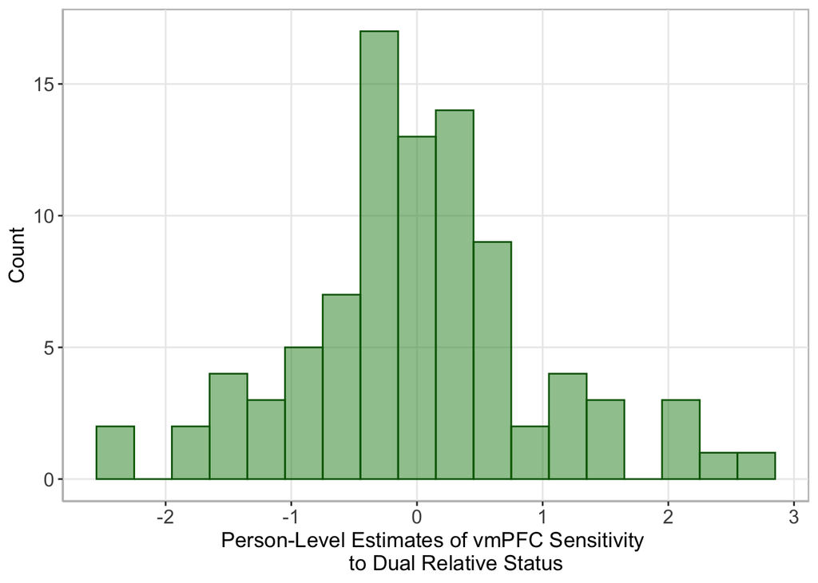

```r
ggplot(d, aes(x = b_mean_cw)) +
        geom_histogram(color = "darkgreen", binwidth = .3,
                     alpha = .5, fill = "forestgreen") +
  labs(x = "Person-Level Estimates of vmPFC Sensitivity
       to Dual Relative Status", y = "Count")
```

# 1 Model 1 (RPI)

Reverse code participants’ scores on the Resistance to Peer Influence (RPI) scale, s.t. higher scores indicate higher **conformity** to peer influence rather than resistance.

```r
d$RPI_final_2 <- 5 - d$RPI_final
```

Check the distribution of the outcome variable: susceptibility to peer influence.

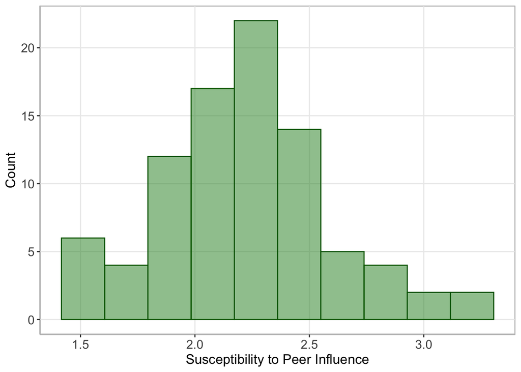

```r
ggplot(d, aes(x = RPI_final_2)) +
        geom_histogram(color = "darkgreen",
                     alpha = .5, bins = 10, fill = "forestgreen") +
  labs(x = "Susceptibility to Peer Influence", y = "Count")
```

Run linear regression model investigating whether participants’ scores on the Resistance to Peer Influence (RPI) scale (reverse-scored) are predicted by vmPFC sensitivity to peers’ higher status in a **dual space that includes information from both the popularity and leadership dimension**. We included the following control variables: year in college, gender, hh income, parents’ education, and nested the intercepts within groups.

```r
# options(mc.cores = parallel::detectCores())
# m2 <- stan_lmer(RPI_final_2 ~ b_mean_cw + college_year_cw + gender_numeric_cw +
#                    income_num_cw + educ_parents_years_cw + (1 | groupID),
#                data = d, seed = 123)
# save(m2, file = sprintf("%s/Model Results/RPI_Dual_Relative_Status_Sensitivity_vmpfc_july2025.RData", path))
```

Check regression results.

```r
# Load model results
load(sprintf("%s/Model Results/RPI_Dual_Relative_Status_Sensitivity_vmpfc_july2025.RData", path))

# Extract the effects from the model
d_table <- tidy(m2, effects = "fixed", conf.int = TRUE, conf.level = 0.95) %>%
  mutate(term = recode(term, "b_mean_cw" = "vmPFC Dual Status Sensitivity",
                       "college_year_cw" = "College Year",
                       "gender_numeric_cw" = "Gender",
                       "income_num_cw" = "HH Income",
                       "educ_parents_years_cw" = "Parents' Education"),
         across(where(is.numeric), ~ round(.x, 2)),
         CI_95 = paste0("[", round(conf.low, 2), ", ", round(conf.high, 2), "]")) %>%
  select(-c(conf.low, conf.high))

# Create a table of results
table <- flextable(d_table) %>%
  set_header_labels(term = "Term",
    estimate = "Beta Estimate",
    std.error = "SE",
    CI_95 = "95% CI") %>%
  autofit() %>%
  theme_booktabs()

# Save to Word document
doc <- read_docx() %>%
  body_add_par("Table: Predictors of Susceptibility to Peer Influence",
               style = "heading 2") %>%
  body_add_flextable(table)

print(doc, target = sprintf("%s/Tables/RPI_Dual_Relative_Status_Sensitivity_vmpfc_july2025.docx", path))

table
```

| Term | Beta Estimate | SE | 95% CI |
| --- | --- | --- | --- |
| (Intercept) | 2.22 | 0.04 | [2.13, 2.3] |
| vmPFC Dual Status Sensitivity | 0.10 | 0.04 | [0.02, 0.18] |
| College Year | 0.01 | 0.04 | [-0.08, 0.09] |
| Gender | -0.06 | 0.04 | [-0.15, 0.03] |
| HH Income | 0.06 | 0.06 | [-0.06, 0.17] |
| Parents' Education | -0.03 | 0.06 | [-0.14, 0.08] |

Check what proportion of the distribution is above zero for the main effect of `b_mean_cw` on `RPI_final_2`.

```r
n <- 4000 # define the number of posterior draws
posterior <- as.data.frame(as.matrix(m2))
round(length(which((posterior$b_mean_cw) > 0))/n*100,1)
```

```
## [1] 99.2
```

Plot the results in a scatterplot.

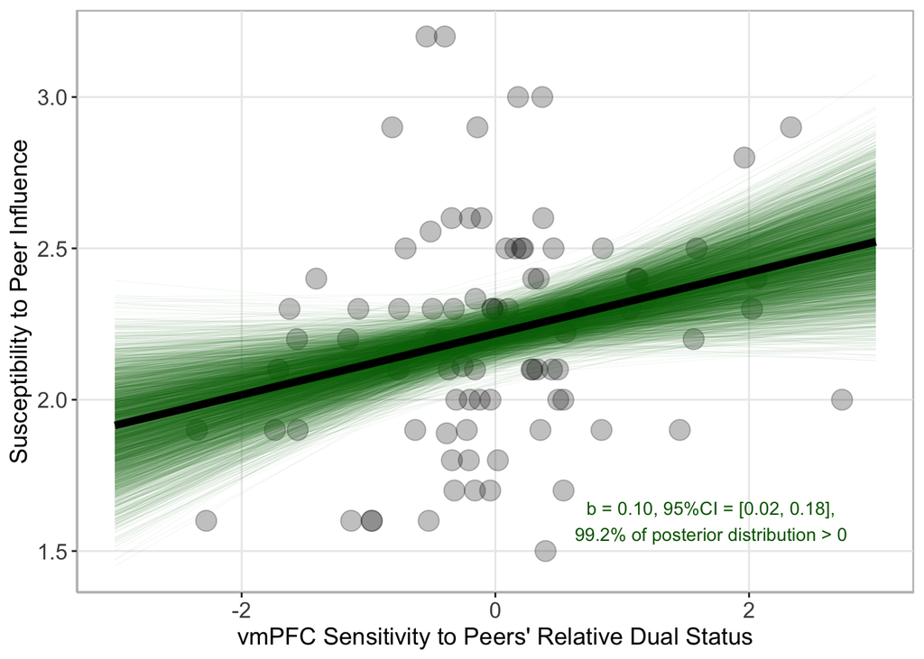

```r
# Extract all posterior distributions
p <- posterior_samples(m2)[, c(1:2)]
colnames(p) <- c("intercept", "b_mean_cw")
p <- p %>%
  dplyr::mutate(draw = 1:n,
         m_int = median(intercept), # Extract fixed effects medians from the model
         m_b_mean_cw = median(b_mean_cw)) # Extract fixed effects medians from the model

# Sample 4000 random draws
nr_random_draws <- 4000 # specify here number of random draws
s <- sample(1:n, nr_random_draws, replace=F)
p <- p %>%
  filter(draw %in% s)

# Add predicted y values for the random draws and fixed effects
p <- p[rep(seq_len(nrow(p)), each = 7), ] %>%
  mutate(seq = rep(-3:3, nr_random_draws)) %>%
  rowwise() %>%
  dplyr::mutate(y_draw = intercept + b_mean_cw * seq,
         y_fe = m_int + m_b_mean_cw * seq)

# Plot results
ggplot(data = d, aes(b_mean_cw, RPI_final_2)) +
  geom_point(size = 5, alpha = .25) +
  labs(x = "vmPFC Sensitivity to Peers' Relative Dual Status",
       y = "Susceptibility to Peer Influence") +
  geom_line(data = p, aes(x = seq, y_draw, group = draw),
              color = "darkgreen", alpha = .1, linewidth = .1) +
  geom_line(data = p, aes(seq, y_fe), color = "black", size = 2) +
  annotate(geom="text", x=1.7, y=1.6,
           label="b = 0.10, 95%CI = [0.02, 0.18],\n99.2% of posterior distribution > 0",
          # color="darkgreen", size = 5.5)
          color="darkgreen", size = 3.5)
```

```r
# ggsave(file = sprintf("%s/Figures/vmPFC_Sensitivity_Dual_Relative_Status_RPI_scatterplot_july2025.tiff", path),
#        plot = last_plot(), width=8, height=7, units = "in", dpi = 600, compression = "lzw")
```

# 2 Model 2 (Drinking in Daily Life)

Open the EMA dataset including 1) a binary variable representing whether or not a participant had any alcohol at a given time point (`HadAlcohol` = 1 if the participant had any drinks; `HadAlcohol` = 0 otherwise) and 2) a continuous variable (`drinks_total`) representing the number of drinks participants consumed when they drank. The EMA portion of the study lasted for 28 days; measures were collected in the morning and evening.

```r
l <- read.csv(sprintf("%s/Data/data_ema.csv", path)) %>%
  select(pID, time_point, HadAlcohol, drinks_total)
```

Check the structure of the dataset.

```r
head(l)
```

|  | pID | time_point | HadAlcohol | drinks_total |
| --- | --- | --- | --- | --- |
| 1 | muri012 | 1 | 0 | NA |
| 2 | muri012 | 2 | 0 | NA |
| 3 | muri012 | 3 | 0 | NA |
| 4 | muri012 | 4 | 0 | NA |
| 5 | muri012 | 5 | 0 | NA |
| 6 | muri012 | 6 | 0 | NA |

Merge datasets.

```r
df <- merge(d,l)
```

Combine the HadAlcohol and drinks_total variables in one variable that is zero is a participant did not drink any alcohol at a given time point, the number of drinks consumed otherwise.

```r
df$drinks_total_2 <- ifelse(df$HadAlcohol == 0, 0, df$drinks_total)
```

Replace outliers with 16 (following rules decided by the MURI team).

```r
df$drinks_total_2 <- ifelse(df$drinks_total_2 > 16, 16, df$drinks_total_2)
```

Check the distribution of the alcohol consumption variable.

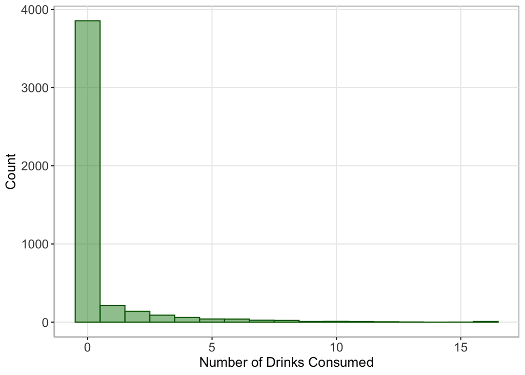

```r
ggplot(df, aes(x = drinks_total_2)) +
        geom_histogram(color = "darkgreen",
                     alpha = .5, fill = "forestgreen",
                     binwidth = 1) +
  labs(x = "Number of Drinks Consumed", y = "Count")
```

Run glmmTMB zero-inflated regression model testing **whether participants drink more or less during the EMA period as a function of their own vmPFC sensitivity to peers’ relative dual status and their group’s approval of binge drinking**.

```r
# m3 <- glmmTMB(drinks_total_2 ~ b_mean_cw * group_att_binge_num_cb + group_att_binge_num_cw +
#                 college_year_cw + gender_numeric_cw + income_num_cw + educ_parents_years_cw  + (1 | groupID:pID),
#                 zi = ~ b_mean_cw * group_att_binge_num_cb + group_att_binge_num_cw +
#                 college_year_cw + gender_numeric_cw + income_num_cw + educ_parents_years_cw  + (1 | groupID:pID),
#              data = df, family = truncated_nbinom2)
# save(m3, file = sprintf("%s/Model Results/Drinking_Dual_Relative_Status_Sensitivity_vmpfc_july2025.RData", path))
```

Check results.

```r
# Load model results
load(sprintf("%s/Model Results/Drinking_Dual_Relative_Status_Sensitivity_vmpfc_july2025.RData", path))

# Extract the effects from the model
d_table <- tidy(m3, effects = "fixed", conf.int = TRUE, conf.level = 0.95) %>%
  mutate(term = recode(term, "b_mean_cw" = "vmPFC Dual Status Sensitivity",
                       "gender_numeric_cw" = "Gender",
                       "income_num_cw" = "HH Income",
                       "educ_parents_years_cw" = "Parents' Education",
                       "group_att_binge_num_cb" = "Group Drinking Norms (BTW)",
                       "group_att_binge_num_cw" = "Group Drinking Norms (WI)",
                       "college_year_cw" = "College Year",
                       "b_mean_cw:group_att_binge_num_cb" = "vmPFC Dual Status Sensitivity x Group Drinking Norms (BTW) Interaction"),
         Model = recode(component, "cond" = "Conditional",
                            "zi" = "Zero-Inflation"),
         across(where(is.numeric), ~ round(.x, 2)),
         CI_95 = paste0("[", round(conf.low, 2), ", ", round(conf.high, 2), "]")) %>%
  select(Model, term, estimate, std.error, CI_95, p.value)

# Create a table of results
table <- flextable(d_table) %>%
  set_header_labels(term = "Term",
    estimate = "Beta Estimate",
    std.error = "SE",
    CI_95 = "95% CI") %>%
  autofit() %>%
  theme_booktabs()

# Save to Word document
doc <- read_docx() %>%
  body_add_par("Table: Predictors of Drinking in Daily Life",
               style = "heading 2") %>%
  body_add_flextable(table)

print(doc, target = sprintf("%s/Tables/Drinking_Dual_Relative_Status_Sensitivity_vmpfc_july2025.docx", path))

table
```

| Model | Term | Beta Estimate | SE | 95% CI | p.value |
| --- | --- | --- | --- | --- | --- |
| Conditional | (Intercept) | 0.81 | 0.08 | [0.65, 0.97] | 0.00 |
| Conditional | vmPFC Dual Status Sensitivity | -0.09 | 0.08 | [-0.25, 0.07] | 0.26 |
| Conditional | Group Drinking Norms (BTW) | 0.10 | 0.15 | [-0.19, 0.39] | 0.51 |
| Conditional | Group Drinking Norms (WI) | 0.05 | 0.07 | [-0.09, 0.18] | 0.52 |
| Conditional | College Year | -0.07 | 0.08 | [-0.22, 0.08] | 0.36 |
| Conditional | Gender | -0.20 | 0.08 | [-0.36, -0.04] | 0.01 |
| Conditional | HH Income | 0.02 | 0.11 | [-0.19, 0.23] | 0.84 |
| Conditional | Parents' Education | 0.01 | 0.10 | [-0.19, 0.21] | 0.90 |
| Conditional | vmPFC Dual Status Sensitivity x Group Drinking Norms (BTW) Interaction | 0.36 | 0.16 | [0.04, 0.67] | 0.03 |
| Zero-Inflation | (Intercept) | 2.02 | 0.10 | [1.82, 2.22] | 0.00 |
| Zero-Inflation | vmPFC Dual Status Sensitivity | -0.05 | 0.12 | [-0.27, 0.18] | 0.70 |
| Zero-Inflation | Group Drinking Norms (BTW) | -0.15 | 0.23 | [-0.59, 0.29] | 0.50 |
| Zero-Inflation | Group Drinking Norms (WI) | 0.00 | 0.11 | [-0.22, 0.22] | 0.97 |
| Zero-Inflation | College Year | -0.41 | 0.11 | [-0.63, -0.19] | 0.00 |
| Zero-Inflation | Gender | 0.10 | 0.12 | [-0.14, 0.34] | 0.40 |
| Zero-Inflation | HH Income | -0.05 | 0.15 | [-0.35, 0.26] | 0.76 |
| Zero-Inflation | Parents' Education | 0.00 | 0.15 | [-0.29, 0.29] | 0.98 |
| Zero-Inflation | vmPFC Dual Status Sensitivity x Group Drinking Norms (BTW) Interaction | 0.01 | 0.23 | [-0.43, 0.46] | 0.95 |

Plot the relationship between vmPFC sensitivity to peers with higher relative dual status and the estimated number of drinks consumed during the EMA study period separately for participants in groups with low approval of binge drinking (operatinalized as 1.5 SD below the mean) and for participants in groups with high approval of binge drinking (operatinalized as 1.5 SD above the mean).

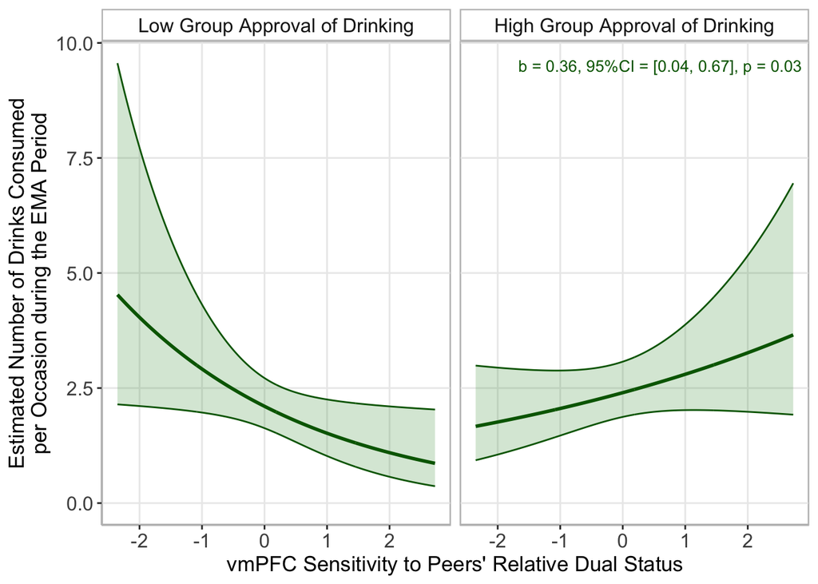

```r
vals_beta = seq(min(df$b_mean_cw, na.rm = T), max(df$b_mean_cw, na.rm = T), .01)
vals_att = c(round((mean(df$group_att_binge_num_cb, na.rm = T) - 1.5 * sd(df$group_att_binge_num_cb, na.rm = T)),2),
             round((mean(df$group_att_binge_num_cb, na.rm = T) + 1.5 * sd(df$group_att_binge_num_cb, na.rm = T)),2))

predicted = ggeffects::ggpredict(m3, c("b_mean_cw [vals_beta]",
                                      "group_att_binge_num_cb [vals_att]"),
                                 type = "fe") %>%
  data.frame() %>%
  rowwise() %>%
  mutate(group_labels = ifelse(group == -0.66, "Low Group Approval of Drinking",
                               "High Group Approval of Drinking"),
         group_labels = factor(group_labels,
                               levels = c("Low Group Approval of Drinking",
                               "High Group Approval of Drinking")))

dat_text <- data.frame(
  label = c("",
            "b = 0.36, 95%CI = [0.04, 0.67], p = 0.03"),
  group_labels = factor(c("Low Group Approval of Drinking",
                        "High Group Approval of Drinking")),
  x = c(0,0.6), y = c(0,9.5))
predicted %>%
  ggplot(aes(x, predicted)) +
  geom_ribbon(aes(ymin = conf.low, ymax = conf.high),
              alpha = .2, color = "darkgreen", fill = "forestgreen") +
  geom_line(linewidth = 1, color = "darkgreen") +
  facet_wrap(~group_labels) +
  labs( x = "vmPFC Sensitivity to Peers' Relative Dual Status",
        y = "Estimated Number of Drinks Consumed\nper Occasion during the EMA Period") +
  geom_text(data = dat_text,
  mapping = aes(x = x, y = y, label = label),
  color = "darkgreen",
  # size = 5.5)
  size = 3.5)
```

```r
# ggsave(file = sprintf("%s/Figures/vmPFC_Sensitivity_Dual_Relative_Status_Group_Approval_Drinking_july2025.tiff", path),
#        plot = last_plot(), width=11, height=7, units = "in", dpi = 600, compression = "lzw")
```